# Figure 1. Root microbiota and rice genotype co-contribute to the variation in tiller number of a field-grown rice population

Yong-Xin Liu

2020-11-18

Note: Non-letters are sometimes illegal variable names. In the analysis, the subspecies name aus, indica, tropical japonica and temperate japonica is abbreviated as AUS, IND, TRJ and TEJ.

## 1A. Unrooted phylogenetic tree

Note: the following script need running in Bash command line.

```
# Construct phylogenetic tree by by IQ-TREE v1.6.12
gunzip merge_seq.fa.gz # decompress
iqtree -s merge_seq.fa -st DNA -m TEST -bb 1000 -alrt 1000 -nt 20 -pre iqtree165 -quiet
# Generate annotation file
# Note: table2itol.R from https://github.com/mgoeker/table2itol
Rscript ../script/table2itol.R -a -d -c none -D planB -b Subspecies -i OTUID -l OTUID -t %s -w 0.5 ../data/cultivar.txt
```

Then the tree file is visulized in iTOL (https://itol.embl.de/). Add tree color file (iTOL_treecolors-Subspecies.txt) as annotation. Save file as 1a.Tree165SubSpecies.svg

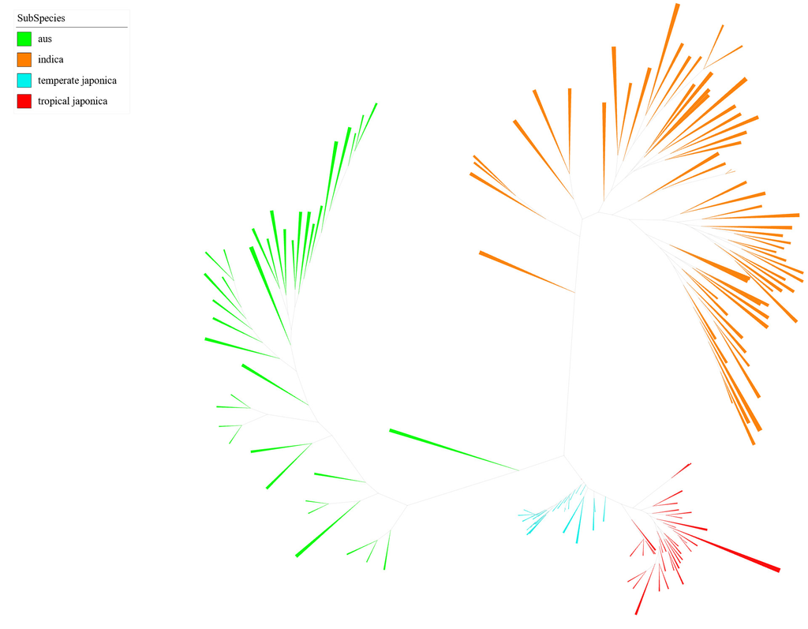

## 1B. The experimental design used for the field trials

This drawing is hand-drawn and drawn using Adobe Illustrator.

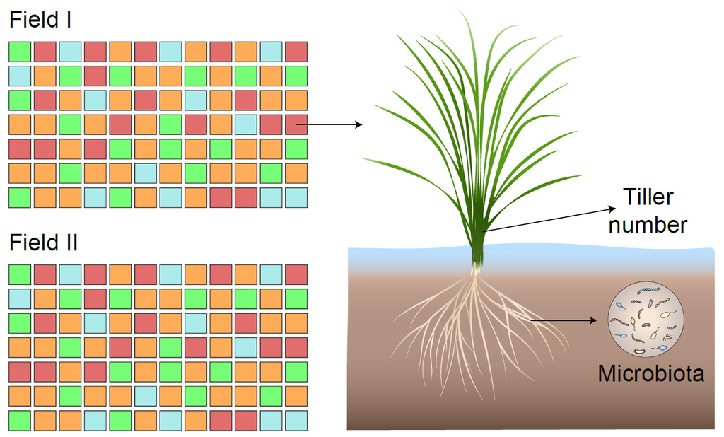

### S1A. Rank abundance plot

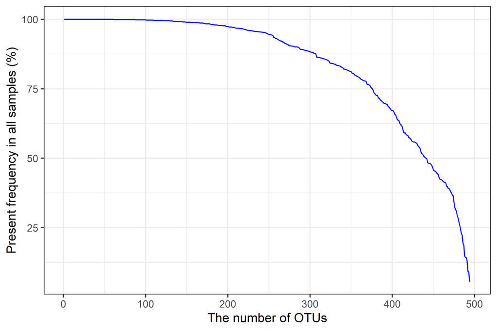

```r
otutab_metadata = read.table("../data/miniCore_otutab_metadata.txt", header=T, row.names=1, sep="\t", comment.char="", stringsAsFactors=F)
otutab_metadata$ID = 1:dim(otutab_metadata)[1]
# Frequency line plot
(g1 = ggplot(otutab_metadata, aes(ID, frequent)) + geom_line(colour = 'blue') + labs(x = "The number of OTUs", y = 'Present frequency in all samples (%)') + theme_bw())
```

```r
# Add vertical line in 90%OTUs
(p90 = table(otutab_metadata$frequent>=90)[2])
```

```
TRUE
 285
```

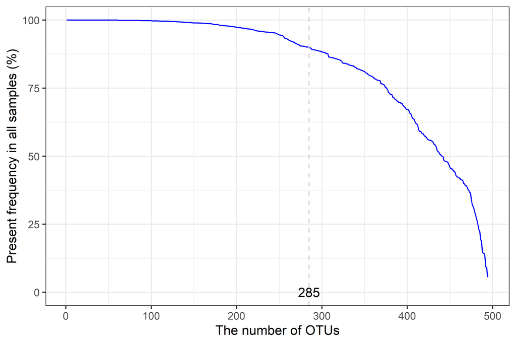

```r
(g1 = g1 + geom_vline(xintercept=p90, linetype=2, color="lightgrey") +
  annotate("text",x=p90,y=0,label=p90))
```

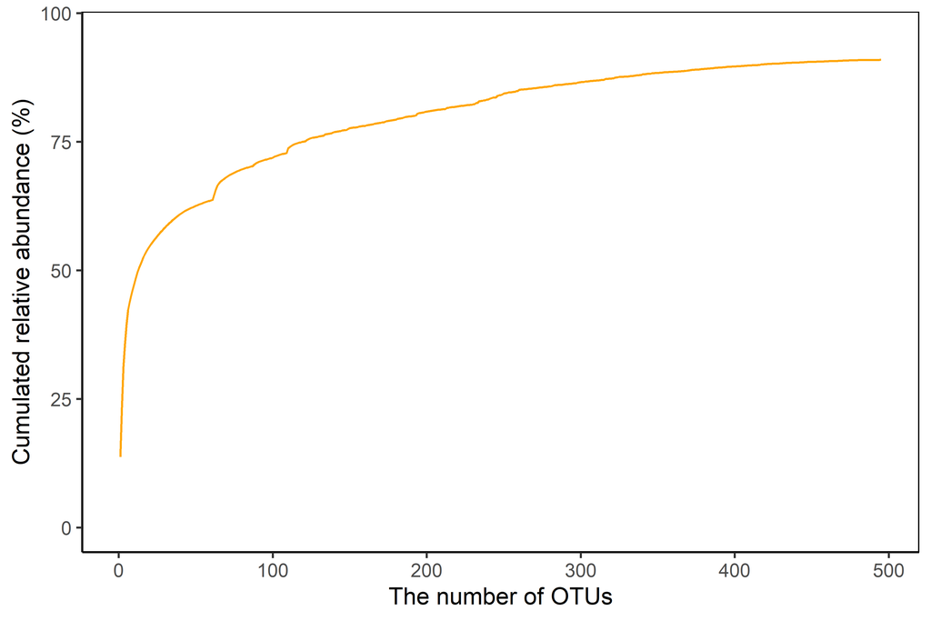

```r
# Accumulated line plot, and manual set ylim
(g2 <- ggplot(otutab_metadata, aes(ID, accumulate)) + geom_line(colour = 'orange') + labs(x = "The number of OTUs", y = 'Cumulated relative abundance (%)') + ylim(0,95.5) + theme_classic()%+replace% theme(panel.background = element_rect(fill = NA)))
```

```r
# Add horizontal line in relative abundance of 90% OTUs
(a90 = otutab_metadata[p90, "accumulate"])
```

```
[1] 86.02874
```

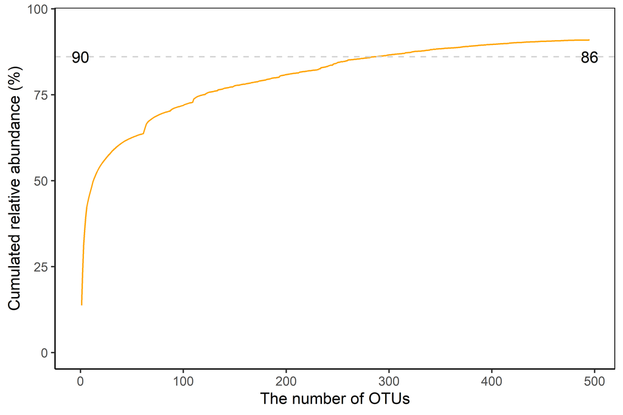

```r
(g2 = g2 + geom_hline(yintercept=a90, linetype=2, color="lightgrey") +
  annotate("text",x=dim(otutab_metadata)[1],y=a90,label=round(a90,1))+
  annotate("text",x=0,y=a90,label="90"))
```

```r
ggsave(paste("S1b.accumulate.pdf", sep=""), ggplot2.two_y_axis(g1, g2), width = w*1.5, height = h*1.5, units = "mm")
```

## 1C. Order-level distribution of the 285 root OTUs

```r
core = read.table("../data/miniCore_otutabCorenorm.txt", header=T, row.names=1, sep="\t", comment.char="", stringsAsFactors=F)
taxonomy = read.table("../data/miniCore_taxonomy.txt", header=T, row.names=1, sep="\t", comment.char="", stringsAsFactors=F)

# Merge metadata to data, collapse by order
taxonomy = cbind(taxonomy$Order, core)
colnames(taxonomy)[1]="Order"
Order =  taxonomy %>% group_by(Order) %>% summarise_all(sum)
Order = as.data.frame(Order)

# Decreasing by relative abundance
idx=order(rowMeans(Order[,-1]), decreasing = T)
Order = Order[idx,]
sum(rowMeans(Order[,-1]))
```

```
[1] 86.0287
```

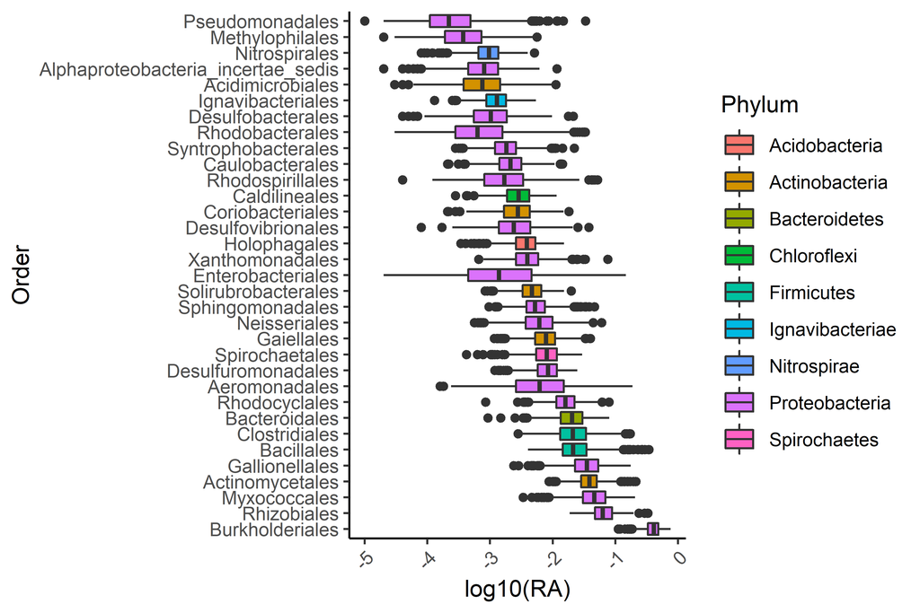

```r
# Save data for plot
write.table("Order\t", file=paste("../data/miniCore_taxonomy_order.txt",sep = ""), append = F, sep="\t", quote=F,  eol = "",row.names=F, col.names=F)
suppressWarnings(write.table(Order, file=paste("../data/miniCore_taxonomy_order.txt",sep = ""), append = T, sep="\t", quote=F, row.names=T, col.names=T))

# Wide table format to ggplot2 long table
colnames(Order)[1] = "ID"
data_all = melt(Order, id.vars = "ID")
data_all$ID = factor(data_all$ID, levels =Order$ID)

# Set the phylum of the order
order_anno = read.table("../data/taxonomy_phylum_order.txt", header=F, row.names=NULL, sep="\t", comment.char="", stringsAsFactors=F)
colnames(order_anno) = c("Phylum","Order")
data_all = merge(data_all, order_anno, by.x = "ID", by.y = "Order", all.x = T, duplicateGeoms = F)
data_all= na.omit(data_all)

# log10 transform
data_all$RA = log10(data_all$value/100)

# Plotting
p = ggplot(data_all, aes(x=ID, y = RA, fill = Phylum )) +
  geom_boxplot()+ coord_flip() +
  theme(axis.ticks.x = element_blank(), axis.text.x = element_blank())+
  xlab("Order")+ylab("log10(RA)")+ theme_classic()+
  theme(axis.text.x=element_text(angle=45,vjust=1, hjust=1),legend.position="right")
p
```

Beautify: sort items by order, manual modify row names, column labels

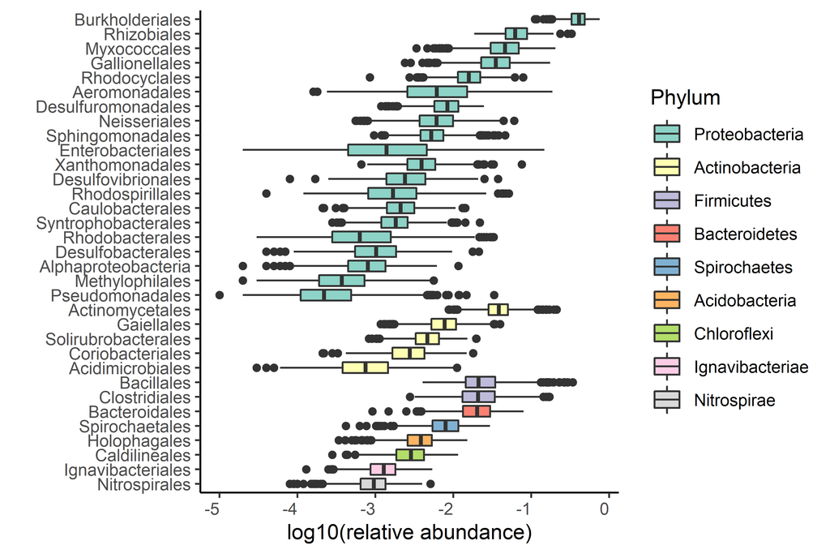

```r
# sort items by order
data_all$Phylum = factor(data_all$Phylum, levels = unique(data_all$Phylum))
group_phylum =  data_all[,c("Phylum","value")] %>% group_by(Phylum) %>% summarise_all(sum)
group_phylum = as.data.frame(group_phylum)
idx = order(group_phylum$value, decreasing = T)
group_phylum = group_phylum[idx,]
# define phylum order
data_all$Phylum = factor(data_all$Phylum, levels = group_phylum$Phylum)

# Sort first by phylum, second by order (relative abundance)
Order_sort = cbind(as.character(Order$ID), 1:dim(Order)[1])
Order_sort = as.data.frame(Order_sort, stringsAsFactors = F)
colnames(Order_sort) = c("Order","Order_idx")
Order_phylum_sort = merge(Order_sort, order_anno, by.x = "Order", by.y = "Order", all.x = T, duplicateGeoms = F)
Order_phylum_sort = na.omit(Order_phylum_sort)
group_phylum$value=1:dim(group_phylum)[1]
Order_phylum_sort2 = merge(Order_phylum_sort, group_phylum, by.x = "Phylum", by.y = "Phylum", all.x = T, duplicateGeoms = F)
Order_phylum_sort2$Order_idx = as.numeric(Order_phylum_sort2$Order_idx)
Order_phylum_sort2 = arrange(Order_phylum_sort2, desc(value), desc(Order_idx))
# Short ID
data_all$ID = factor(gsub("_.*", "",data_all$ID, perl=T), levels = gsub("_.*", "",Order_phylum_sort2$Order, perl=T))

# Plotting
p = ggplot(data_all, aes(x=ID, y = RA, fill = Phylum )) +
  geom_boxplot()+ coord_flip() +
  theme(axis.ticks.x = element_blank(), axis.text.x = element_blank())+
  xlab("")+ylab("log10(relative abundance)")+ theme_classic()+
  theme(axis.text.x=element_text(angle=0,vjust=1, hjust=1),legend.position="right")
# Adjust the color scheme
library(RColorBrewer)
# display.brewer.all()
p1 = p + scale_fill_brewer(palette = "Set3")
p1
```

```r
ggsave(paste("1c.miniCore_boxplot_Order.pdf", sep=""), p1, width = w*1.5, height = h*1.5, units = "mm")
```

## 1D. Constrained PCoA with Bray–Curtis distance of the root microbiota by subspecies in field I

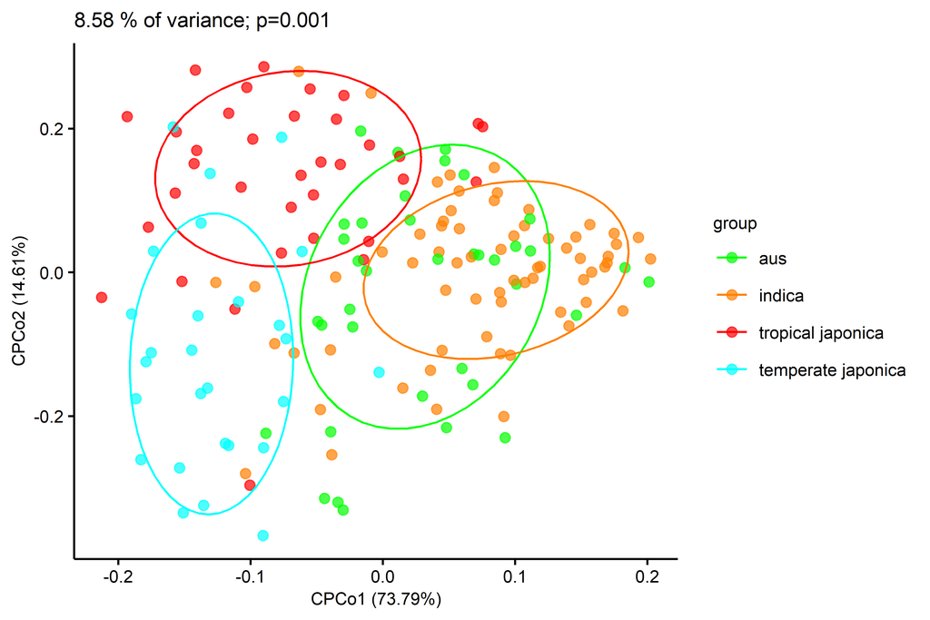

```r
metadata = read.table("../data/cultivar_LN_metadata.txt", header=T, row.names=1, sep="\t", comment.char="", stringsAsFactors=F)
# Set subspecies level
level=c("AUS","IND","TRJ","TEJ" )
metadata$group = factor(metadata$Subspecies, level)
levels(metadata$group) = c("aus","indica","tropical japonica","temperate japonica")

sub_design = metadata
m = "bray"
beta = read.table(paste("../data/cultivar_LN_otutab_norm.txt",sep=""), header=T, row.names=1, sep="\t", comment.char="")

# Extract only those samples in common between the two tables
idx = rownames(sub_design) %in% colnames(beta)
sub_design=sub_design[idx,]
sub_beta=beta[,rownames(sub_design)]

# normalize to 100
otutab = t(sub_beta)/colSums(sub_beta,na=T)*100

# Constrained analysis OTU table by genotype
capscale.gen = capscale(otutab ~ group, data=sub_design, add=F, sqrt.dist=T, distance= m)

# ANOVA-like permutation analysis
perm_anova.gen = anova.cca(capscale.gen, permutations = 1000, parallel = 9)

# generate variability tables and calculate confidence intervals for the variance
var_tbl.gen = variability_table(capscale.gen)
eig = capscale.gen$CCA$eig
variance = var_tbl.gen["constrained", "proportion"]
p.val = perm_anova.gen[1, 4]

# extract the weighted average (sample) scores
points = capscale.gen$CCA$wa
# save coordinate site
write.table("Axis\t", file=paste("1d.cpcoa.txt",sep = ""), append = F, sep="\t", quote=F,  eol = "",row.names=F, col.names=F)
suppressWarnings(write.table(points, file=paste("1d.cpcoa.txt",sep = ""), append = T, sep="\t", quote=F, row.names=T, col.names=T))

points = capscale.gen$CCA$wa[, 1:2]
points = as.data.frame(points)
points = cbind(points, sub_design$group)
colnames(points) = c("PC1", "PC2", "group")
# The picture is reversed horizontally (optional)
points$PC2 = points$PC2 * -1

# plot PC 1 and 2
p = ggplot(points, aes(x=PC1, y=PC2, color=group)) + geom_point(alpha=.7, size=2) +
    labs(x=paste("CPCo1 (", format(100 * eig[1] / sum(eig), digits=4), "%)", sep=""),
    y=paste("CPCo2 (", format(100 * eig[2] / sum(eig), digits=4), "%)", sep="")) +
    ggtitle(paste(format(100 * variance, digits=3), " % of variance; p=",format(p.val, digits=2),sep="")) +
    theme_classic() + main_theme
p = p + stat_ellipse(level=0.68)
color = c("#00FF00","#FF8000", "#FF0000", "#00FFFF" )
p = p + scale_color_manual(values = color)
p
```

```r
ggsave(paste("1d.LN_beta_cpcoa.pdf", sep=""), p, width = w*1.25, height = h*1.15, units = "mm")
```

### S2A. Constrained PCoA with Bray–Curtis distance of the root microbiota by subspecies in field II

```r
metadata = read.table("../data/cultivar_HN_metadata.txt", header=T, row.names=1, sep="\t", comment.char="", stringsAsFactors=F)
level=c("AUS","IND","TRJ","TEJ" )
metadata$group = factor(metadata$Subspecies, level)
levels(metadata$group) = c("aus","indica","tropical japonica","temperate japonica")

sub_design = metadata
m = "bray"
beta = read.table(paste("../data/cultivar_HN_otutab_norm.txt",sep=""), header=T, row.names=1, sep="\t", comment.char="")

idx = rownames(sub_design) %in% colnames(beta)
sub_design=sub_design[idx,]
sub_beta=beta[,rownames(sub_design)]
otutab = t(sub_beta)/colSums(sub_beta,na=T)*100

# Constrained analysis OTU table by genotype
capscale.gen = capscale(otutab ~ group, data=sub_design, add=F, sqrt.dist=T, distance= m)

# ANOVA-like permutation analysis
perm_anova.gen = anova.cca(capscale.gen, permutations = 1000, parallel = 9)

# generate variability tables and calculate confidence intervals for the variance
var_tbl.gen = variability_table(capscale.gen)
eig = capscale.gen$CCA$eig
variance = var_tbl.gen["constrained", "proportion"]
p.val = perm_anova.gen[1, 4]

points = capscale.gen$CCA$wa
# save coordination
write.table("Axis\t", file=paste("S2a.cpcoa.txt",sep = ""), append = F, sep="\t", quote=F,  eol = "",row.names=F, col.names=F)
suppressWarnings(write.table(points, file=paste("S2a.cpcoa.txt",sep = ""), append = T, sep="\t", quote=F, row.names=T, col.names=T))

# extract the weighted average (sample) scores
points = capscale.gen$CCA$wa[, 1:2]
points = as.data.frame(points)
points = cbind(points, sub_design$group)
colnames(points) = c("PC1", "PC2", "group")
points$PC2 = points$PC2

# plot PC 1 and 2
p = ggplot(points, aes(x=PC1, y=PC2, color=group)) + geom_point(alpha=.7, size=2) +
    labs(x=paste("CPCo1 (", format(100 * eig[1] / sum(eig), digits=4), "%)", sep=""),
    y=paste("CPCo2 (", format(100 * eig[2] / sum(eig), digits=4), "%)", sep="")) +
    ggtitle(paste(format(100 * variance, digits=3), " % of variance; p=",format(p.val, digits=2),sep="")) +
    theme_classic() + main_theme
p = p + stat_ellipse(level=0.68)
color = c("#00FF00","#FF8000", "#FF0000", "#00FFFF" )
p = p + scale_color_manual(values = color)
ggsave(paste("S2a.HN_beta_cpcoa.pdf", sep=""), p, width = w*1.25, height = h*1.15, units = "mm")
```

## 1E. Root microbiota show the same clustering patterns as tiller number and population structure of the field-grown rice population

Root microbiota + Phenotype(Tiller number) + Genotype

### Left. Clustering of root microbiota

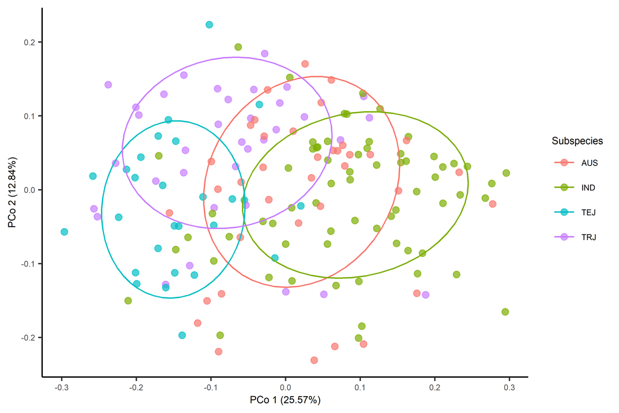

```r
library(dplyr)
metadata = read.table(paste("../data/cultivar_LN_metadata.txt",sep=""), header=T, row.names=1, sep="\t", comment.char="")
distance_type = "bray_curtis"
distance_mat = read.table(paste0("../data/cultivar_LN_",distance_type,".txt"), header=T, row.names=1, sep="\t", comment.char="")
# distance_mat[1:3, 1:3]

# amplicon packages from github: https://github.com/microbiota/amplicon
library(amplicon)
# Plotting Constrained PCoA based on distance matrix
(p = beta_pcoa(distance_mat, metadata, groupID = "Subspecies"))
```

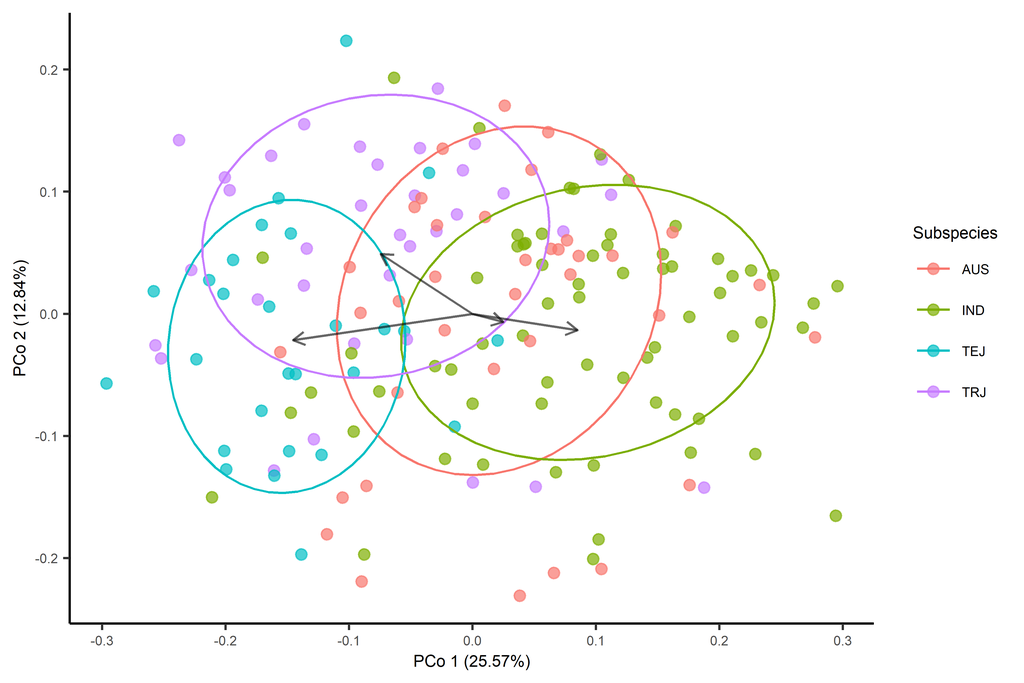

```r
# Add arrow
points = p$data
arrows_pos = points %>% group_by(group) %>% summarise_all(mean)
arrows_pos = as.data.frame(arrows_pos)
arrows_pos$x_start = 0
arrows_pos$y_start = 0
p = p + geom_segment(data = arrows_pos, aes(x = x_start, y = y_start, xend = x, yend = y),
                  arrow = arrow(length = unit(0.2, "cm")),color="black",alpha=0.6)
p
```

```r
# set scale to save plot
x = 0.2557
y= 0.1284
ggsave(paste0("1e.LN_pcoa_",distance_type,"_arrow_scale.pdf"), p, width = 89, height = 89*y/x, units = "mm")
```

PCoA plot cluster into dendrogram

```r
# scaling by expained variance
arrows_pos$x = arrows_pos$x * x
arrows_pos$y = arrows_pos$y * y
# calculate euclidean distance
df = arrows_pos[,2:3]
rownames(df) = arrows_pos$group

dat_dist <- vegdist(df, method="euclidean")
# hclust
dat_dist_clu <- hclust(dat_dist, "average")
# plot
pdf(paste0("1e.LN_pcoa_",distance_type,"_hclust.pdf"), width=4, height=3)
plot(dat_dist_clu, main = "Hclust with euclidean", lwd=1.5, cex=.5)
dev.off()
```

### Middle. Tiller number boxplot

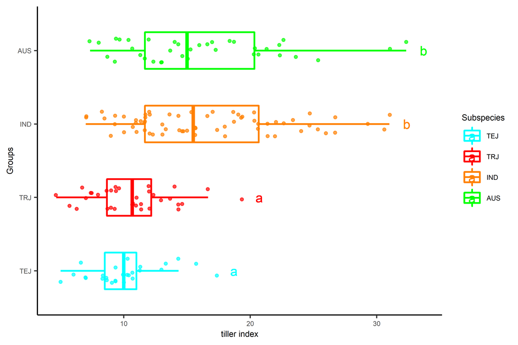

```r
phenoLN = read.table("../data/cultivar_LN_pheno.txt", header=T, row.names=1, sep="\t", comment.char="", stringsAsFactors=F)
design = read.table("../data/cultivar_LN_metadata.txt", header=T, row.names=1, sep="\t", comment.char="")
phenoLN = phenoLN[rownames(design),]
design$Subspecies = factor(design$Subspecies, levels = c("TEJ","TRJ","IND","AUS"))
library(amplicon)
write.table(cbind(design, phenoLN[rownames(design),]), file=paste("../data/cultivar_LN_pheno_metadata.txt", sep="_"), append = F, sep="\t", quote=F, row.names=F, col.names=T)
p = alpha_boxplot(phenoLN, design, index = "tiller", "Subspecies")
p = p + coord_flip(clip = "on")
color = c("#00FFFF", "#FF0000", "#FF8000", "#00FF00")
p = p + scale_color_manual(values = color)
p
```

```r
ggsave(paste("1d.tiller_LN_subspecies.pdf", sep=""), p, width = 4, height =4 )
```

### Right. Rice population structure

Note: the following script need running in Bash command line.

Construct subspecies tree. Using ARO as outgroup.

All the related scripts in folder script.

```bash
# decompress SNP sequences
gunzip merge_clean.fa.gz
# get SNP sequences in each subspecies
for i in IND TEJ TRJ AUS ARO; do
  # Select subspecies ID
  grep -P "\t${i}$" ../doc/minicore_subspecies.txt | cut -f 1 > temp/subspecies_${i}.id
  # get sequences by usearch v10.0
  usearch10 -fastx_getseqs data/merge_clean.fa -labels temp/subspecies_${i}.id -fastaout temp/subspecies_${i}.fa
  # transform multiply sequences fasta in one line format
  format_fasta_1line.pl -i temp/subspecies_${i}.fa -o temp/subspecies_${i}1.fa
  # get consensus sequences in each subspecies
  consensus_fa.pl -i temp/subspecies_${i}1.fa -o temp/subspecies_${i}_consensus
done
cat temp/subspecies_*_consensus.fa > temp/consensus.fa
sed -i 's/subspecies_//;s/_consensus//' temp/consensus.fa
iqtree -s temp/consensus.fa -st DNA -m TEST -bb 1000 -alrt 1000 -nt 20 -pre fig1/subspecies5 -quiet -redo
```

Then the tree file is visulized in iTOL (https://itol.embl.de/). Save file as subspecies5_branch.svg and subspecies5_branchno.svg

### S2B. Root microbiota show the same clustering patterns as tiller number and population structure of the field-grown rice population in field II

Root microbiota + Phenotype(Tiller number) + Genotype

#### Left. Clustering of root microbiota

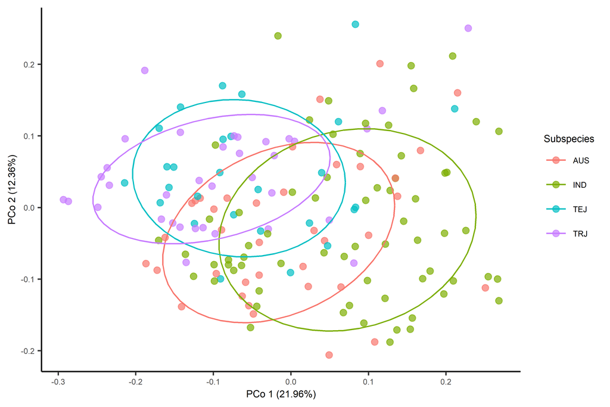

```r
library(dplyr)
metadata = read.table(paste("../data/cultivar_HN_metadata.txt",sep=""), header=T, row.names=1, sep="\t", comment.char="")
distance_type = "bray_curtis"
distance_mat = read.table(paste0("../data/cultivar_HN_",distance_type,".txt"), header=T, row.names=1, sep="\t", comment.char="")
# distance_mat[1:3, 1:3]

# amplicon packages from github: https://github.com/microbiota/amplicon
library(amplicon)
# Plotting Constrained PCoA based on distance matrix
(p = beta_pcoa(distance_mat, metadata, groupID = "Subspecies"))
```

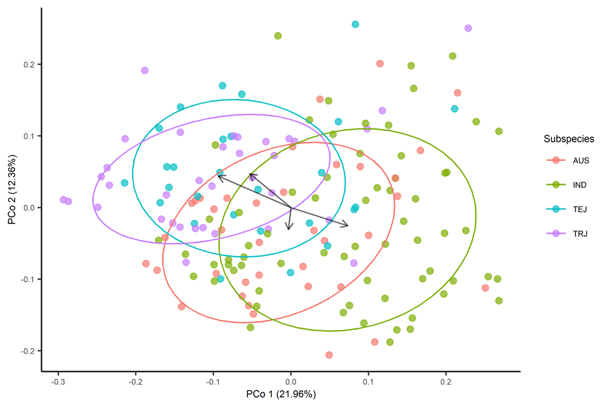

```r
# Add arrow
points = p$data
arrows_pos = points %>% group_by(group) %>% summarise_all(mean)
arrows_pos = as.data.frame(arrows_pos)
arrows_pos$x_start = 0
arrows_pos$y_start = 0
p = p + geom_segment(data = arrows_pos, aes(x = x_start, y = y_start, xend = x, yend = y),
                  arrow = arrow(length = unit(0.2, "cm")),color="black",alpha=0.6)
p
```

```r
# set scale to save plot
x = 0.2196
y= 0.1236
ggsave(paste0("S2b.HN_pcoa_",distance_type,"_arrow_scale.pdf"), p, width = 89, height = 89*y/x, units = "mm")
```

PCoA plot cluster into dendrogram

```r
# scaling by expained variance
arrows_pos$x = arrows_pos$x * x
arrows_pos$y = arrows_pos$y * y
# calculate euclidean distance
df = arrows_pos[,2:3]
rownames(df) = arrows_pos$group

dat_dist <- vegdist(df, method="euclidean")
# hclust
dat_dist_clu <- hclust(dat_dist, "average")
# plot
pdf(paste0("S2b.HN_pcoa_",distance_type,"_hclust.pdf"), width=4, height=3)
plot(dat_dist_clu, main = "Hclust with euclidean", lwd=1.5, cex=.5)
dev.off()
```

#### Middle. Tiller number boxplot

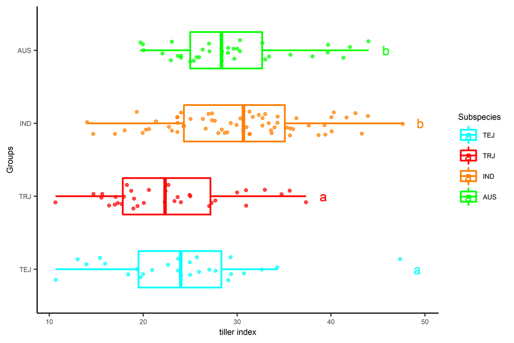

```r
phenoHN = read.table("../data/cultivar_HN_pheno.txt", header=T, row.names=1, sep="\t", comment.char="", stringsAsFactors=F)
design = read.table("../data/cultivar_HN_metadata.txt", header=T, row.names=1, sep="\t", comment.char="")
phenoHN = phenoHN[rownames(design),]
design$Subspecies = factor(design$Subspecies, levels = c("TEJ","TRJ","IND","AUS"))
library(amplicon)
write.table(cbind(design, phenoHN[rownames(design),]), file=paste("../data/cultivar_HN_pheno_metadata.txt", sep="_"), append = F, sep="\t", quote=F, row.names=F, col.names=T)
p = alpha_boxplot(phenoHN, design, index = "tiller", "Subspecies")
p = p + coord_flip(clip = "on")
color = c("#00FFFF", "#FF0000", "#FF8000", "#00FF00")
p = p + scale_color_manual(values = color)
p
```

```r
ggsave(paste("S2b.tiller_HN_subspecies.pdf", sep=""), p, width = 4, height =4 )
```

#### Right. Rice population structure

Same with Figure 1E Right panel.

## 1F. Contributions of root microbiota and rice genotype to the total variation in tiller number in field I

```r
# Tiller number
phenotype = read.table("../data/cultivar_LN_meta.txt", row.names = 1,header = T)
# PCA of genotype
genotype = read.table("../data/genotype.pca.eigenvec", row.names = 1)
genotype = genotype[rownames(phenotype),2:5]
colnames(genotype) = c("PC1","PC2","PC3","PC4")
# PCoA of microbiota
pcoa = read.table("../data/cultivar_LN_bray_curtis14.txt", row.names = 1, header = T)
pcoa = pcoa[rownames(phenotype),]
colnames(pcoa) = c("PCo1","PCo2","PCo3","PCo4")

# merge phenotype, microbiota and genotype
df = cbind(phenotype[,"tiller_raw"], pcoa, genotype)
colnames(df)[1] = "tiller"
# save
suppressWarnings(write.table(df, file=paste("../data/", "cultivar_LN_tiller_M_G.data",sep = ""), append = F, sep="\t", quote=F, row.names=T, col.names=T))

# read file
a <- read.table(paste("../data/", "cultivar_LN_tiller_M_G.data",sep = ""))
fit <- lm(a[,1] ~ a[,2]+a[,3]+a[,4]+a[,5]+a[,6]+a[,7]+a[,8]+a[,9])
# summary
sfit <- summary(fit)
# summary r.squared, also called explained variance
rsquare <- sfit$r.squared
write.table(paste("Microbiota & Genotype",rsquare,sep = "   "),file = "1f.contributionsFieldI.txt", append = TRUE, quote = F, sep=" ", na = "NA", dec = ".", row.names = F, col.names = F)

fit <- lm(a[,1] ~ a[,2]+a[,3]+a[,4]+a[,5])
sfit <- summary(fit)
rsquare <- sfit$r.squared
write.table(paste("Microbiota",rsquare,sep = "  "),file = "1f.contributionsFieldI.txt", append = TRUE, quote = F, sep=" ", na = "NA", dec = ".", row.names = F, col.names = F)

fit <- lm(a[,1] ~ a[,6]+a[,7]+a[,8]+a[,9])
sfit <- summary(fit)
rsquare <- sfit$r.squared
write.table(paste("Genotype",rsquare,sep = "    "),file = "1f.contributionsFieldI.txt", append = TRUE, quote = F, sep=" ", na = "NA", dec = ".", row.names = F, col.names = F)
```

### S2C. Contributions of root microbiota and rice genotype to the total variation in tiller number in field II

```r
# Tiller number
phenotype = read.table("../data/cultivar_HN_meta.txt", row.names = 1,header = T)
# PCA of genotype
genotype = read.table("../data/genotype.pca.eigenvec", row.names = 1)
genotype = genotype[rownames(phenotype),2:5]
colnames(genotype) = c("PC1","PC2","PC3","PC4")
# PCoA of microbiota
pcoa = read.table("../data/cultivar_HN_bray_curtis14.txt", row.names = 1, header = T)
pcoa = pcoa[rownames(phenotype),]
colnames(pcoa) = c("PCo1","PCo2","PCo3","PCo4")

# merge phenotype, microbiota and genotype
df = cbind(phenotype[,"tiller_raw"], pcoa, genotype)
colnames(df)[1] = "tiller"
# save
suppressWarnings(write.table(df, file=paste("../data/", "cultivar_HN_tiller_M_G.data",sep = ""), append = F, sep="\t", quote=F, row.names=T, col.names=T))

# read file
a <- read.table(paste("../data/", "cultivar_HN_tiller_M_G.data",sep = ""))
fit <- lm(a[,1] ~ a[,2]+a[,3]+a[,4]+a[,5]+a[,6]+a[,7]+a[,8]+a[,9])
# summary
sfit <- summary(fit)
# summary r.squared, also called explained variance
rsquare <- sfit$r.squared
write.table(paste("Microbiota & Genotype",rsquare,sep = "   "),file = "S2c.contributionsFieldII.txt", append = TRUE, quote = F, sep="   ", na = "NA", dec = ".", row.names = F, col.names = F)

fit <- lm(a[,1] ~ a[,2]+a[,3]+a[,4]+a[,5])
sfit <- summary(fit)
rsquare <- sfit$r.squared
write.table(paste("Microbiota",rsquare,sep = "  "),file = "S2c.contributionsFieldII.txt", append = TRUE, quote = F, sep="   ", na = "NA", dec = ".", row.names = F, col.names = F)

fit <- lm(a[,1] ~ a[,6]+a[,7]+a[,8]+a[,9])
sfit <- summary(fit)
rsquare <- sfit$r.squared
write.table(paste("Genotype",rsquare,sep = "    "),file = "S2c.contributionsFieldII.txt", append = TRUE, quote = F, sep="   ", na = "NA", dec = ".", row.names = F, col.names = F)
```

### S3. PCA/PCoA Scree plot

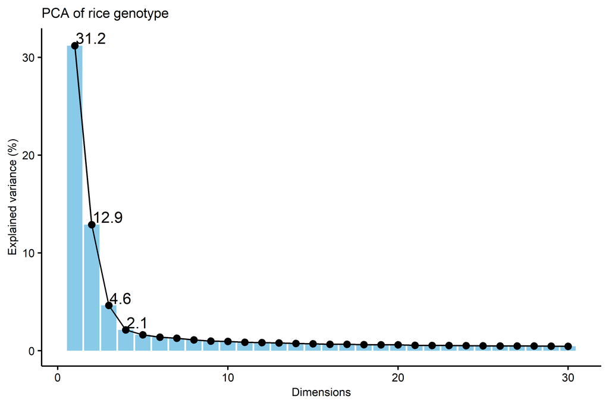

```r
# Read explained variance of genotype PCA and microbiota PCoA
eig = read.table("../data/cultivar_PCA_PCoA_eig.txt", header = T)
# Showing top 30 dimensions
eig = head(eig, n=30)
# Plotting barplot + line plot
library(ggplot2)
p1 = ggplot(eig, aes(Dimensions, Genotype)) +
  geom_bar(stat="identity", fill="#89CAE9") +
  geom_line(colour = 'black') +
  geom_point(shape=21, color="black", fill="black", size=2) +
  geom_text(data=round(head(eig,n=4),digits=1), aes(Dimensions, Genotype, label=Genotype),hjust = 0, nudge_x = 0.05, vjust = 0, nudge_y = 0.2) +
  labs(y="Explained variance (%)",title="PCA of rice genotype")+
   main_theme
p1
```

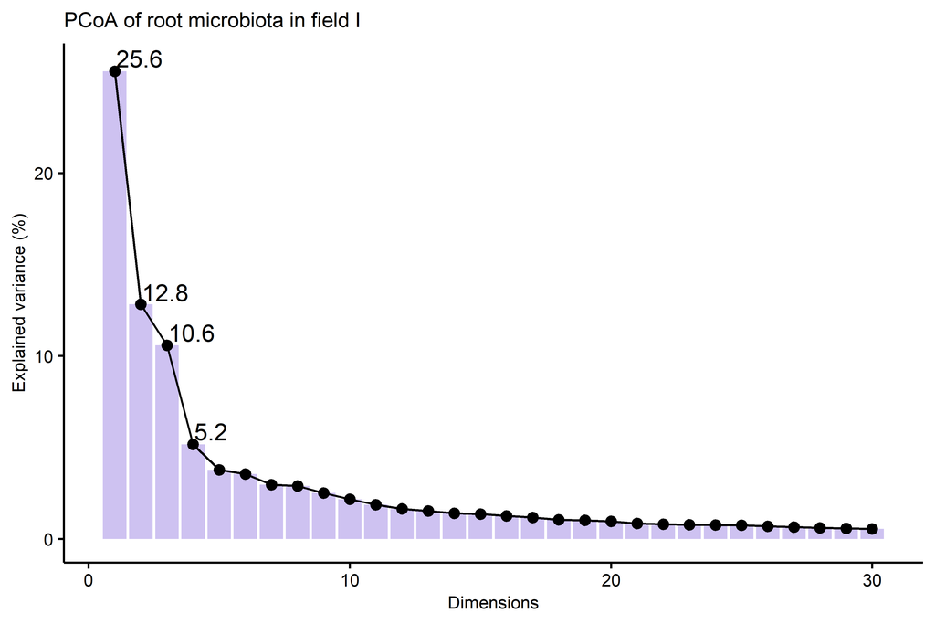

```r
p2 = ggplot(eig, aes(Dimensions, MicrobiotaLN)) +
  geom_bar(stat="identity", fill="#CEC2F1") +
  geom_line(colour = 'black') +
  geom_point(shape=21, color="black", fill="black", size=2) +
  geom_text(data=round(head(eig,n=4),digits=1), aes(Dimensions, MicrobiotaLN, label=MicrobiotaLN),hjust = 0, nudge_x = 0.05, vjust = 0, nudge_y = 0.2) +
  labs(y="Explained variance (%)",title="PCoA of root microbiota in field I")+
   main_theme
p2
```

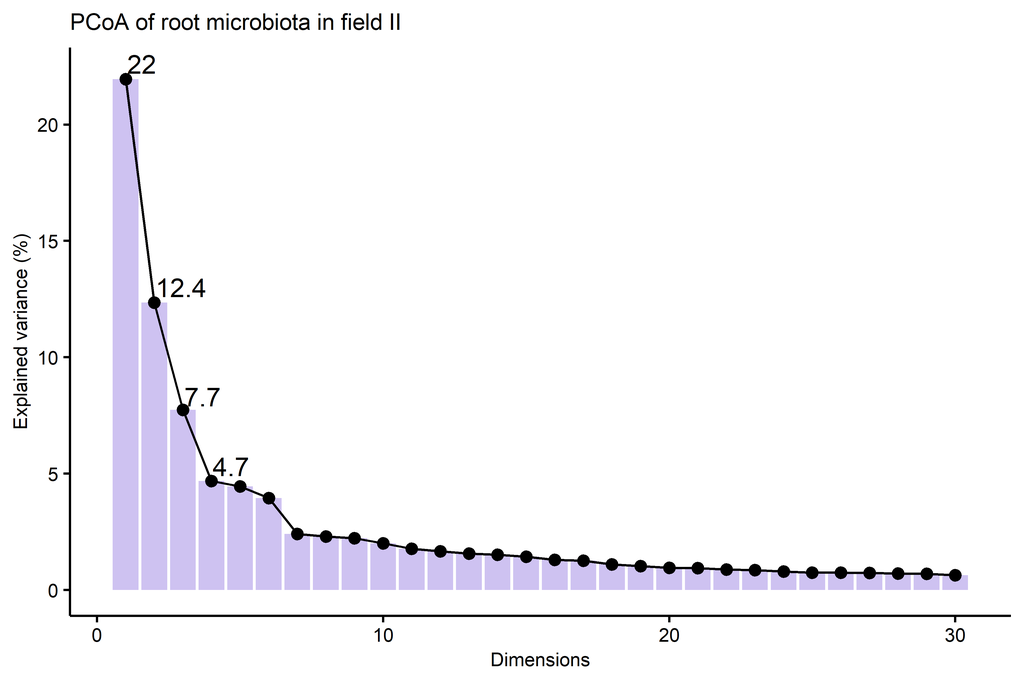

```r
p3 = ggplot(eig, aes(Dimensions, MicrobiotaHN)) +
  geom_bar(stat="identity", fill="#CEC2F1") +
  geom_line(colour = 'black') +
  geom_point(shape=21, color="black", fill="black", size=2) +
  geom_text(data=round(head(eig,n=4),digits=1), aes(Dimensions, MicrobiotaHN, label=MicrobiotaHN),hjust = 0, nudge_x = 0.05, vjust = 0, nudge_y = 0.2) +
  labs(y="Explained variance (%)",title="PCoA of root microbiota in field II")+
   main_theme
p3
```

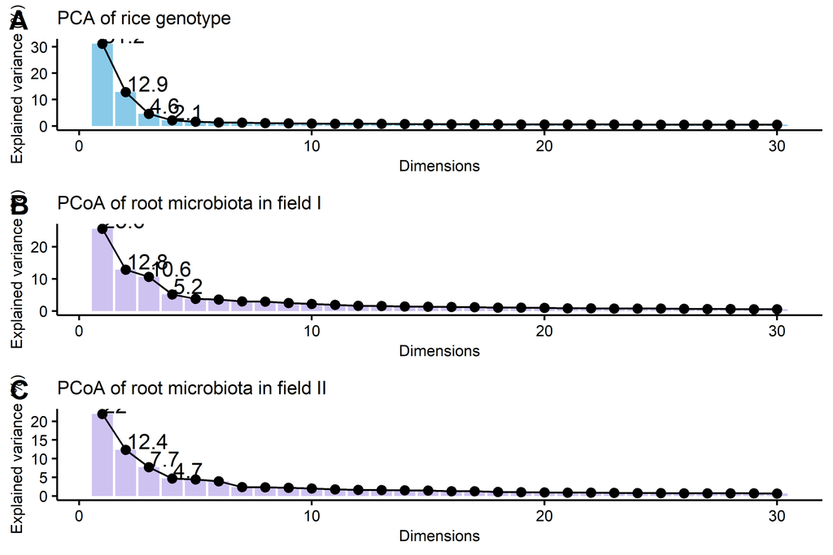

```r
library(cowplot)
(p0 = plot_grid(p1, p2, p3, labels = c("A", "B", "C"), ncol = 1))
```

```r
ggsave("S3.Scree_plot.pdf", p0, width =89*1.5, height = 220, units = "mm")
```